# Social Network Analysis

Amanda Oliveira

2/11/2021

## **1. Application: Classroom Structures**

In this first SNA application I will be generating and analyzing three social networks (also known as graphs or sociograms) based on three different measures. I will be using data from:

Representing Classroom Social Structure. Melbourne: Victoria Institute of Secondary Education, M. Vickers and S. Chan, (1981)

Available from the Index of Complex Networks ([ICON](https://icon.colorado.edu/#!/))

The data were collected by Vickers & Chan from 29 seventh grade students in a school in Victoria, Australia. Students were asked to nominate their classmates on a number of relations including the following three “layers”:

1. Who do you get on with in the class?
2. Who are your best friends in the class?
3. Who would you prefer to work with?

#### **1.1. Data Wrangling**

```r
#install.packages("tidyr")
#install.packages("dplyr")
#install.packages("igraph")
library(tidyr)
library(dplyr)
library(igraph)
getwd()
```

```
## [1] "C:/Users/amand/Documents_AGO/Columbia_Classes/GitHub_Portifolio/Projects/1-Social-Network-Analysis"
```

```r
friends <- read.csv("./data/victoria_data/best.friends.csv", header=T)
friends$from <- as.factor(friends$from)
friends$to <- as.factor(friends$to)

geton <- read.csv("./data/victoria_data/get.on.with.csv", header=T)
geton$from <- as.factor(geton$from)
geton$to <- as.factor(geton$to)

workwith <- read.csv("./data/victoria_data/work.with.csv", header=T)
workwith$from <- as.factor(workwith$from)
workwith$to <- as.factor(workwith$to)
```

#### **1.2. Visualize the Networks**

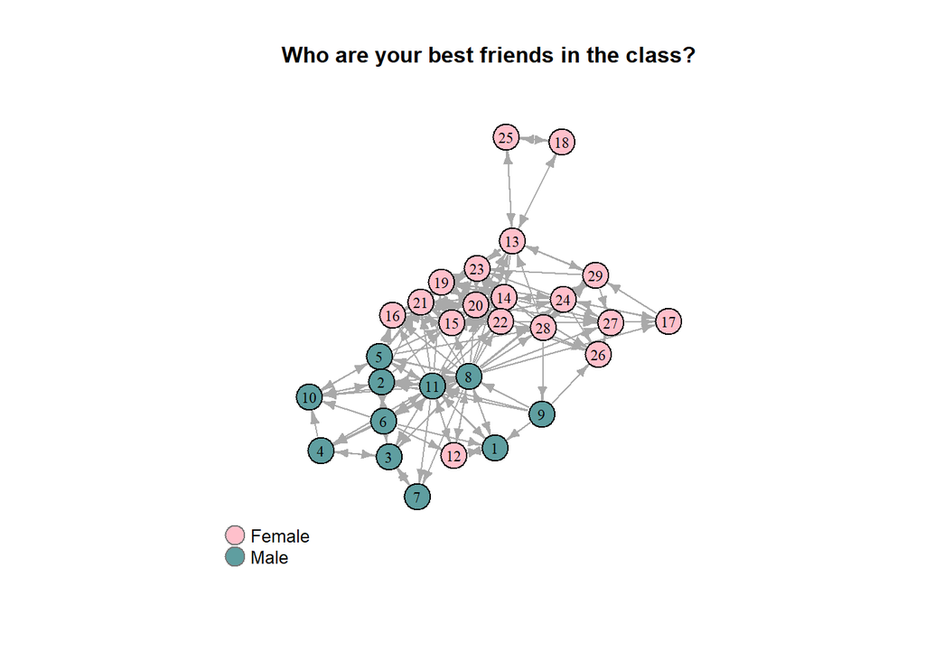

```r
# Friends
e <- select(friends, from, to)
v <- unique(select(friends, from, gender.from))
f <- graph.data.frame(e, directed=T, vertices=v)

V(f)$color=c( "pink", "cadetblue")[1+(V(f)$gender.from=="male")]
V(f)$size=15
V(f)$label.cex=.7
V(f)$label.color="black"
E(f)$arrow.size=.5

# Work With
e1 <- select(workwith, from, to)
v1 <- unique(select(workwith, from, gender.from))
w <- graph.data.frame(e1, directed=T, vertices=v1)

V(w)$color=c( "pink", "cadetblue")[1+(V(w)$gender.from=="male")]
V(w)$size=15
V(w)$label.cex=.7
V(w)$label.color="black"
E(w)$arrow.size=.3

# Get On With
e2 <- select(geton, from, to)
v2 <- unique(select(geton, from, gender.from))
g <- graph.data.frame(e2, directed=T, vertices=v2)

V(g)$color=c( "pink", "cadetblue")[1+(V(w)$gender.from=="male")]
V(g)$size=15
V(g)$label.cex=.7
V(g)$label.color="black"
E(g)$arrow.size=.3

# GRAPH
# par(mfrow=c(1,3))

#pdf(file="Friends.pdf")
set.seed(77)
plot(f, layout=layout.fruchterman.reingold)
title("Who are your best friends in the class?", cex.main=1, col.main="black")
legend(x=-1.5, y=-1.1, c("Female","Male"), pch=21,col="#777777", pt.bg=c("pink", "cadetblue"), pt.cex=2, cex=.8, bty="n", ncol=1)
```

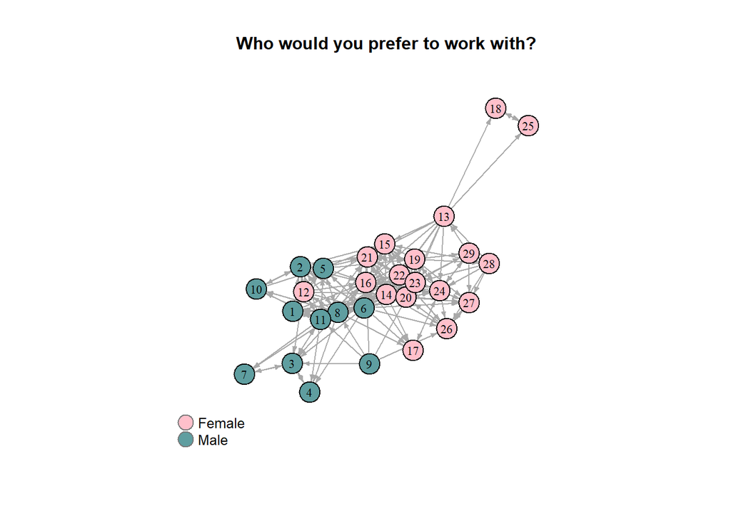

```r
#pdf(file="WorkWith.pdf")
set.seed(77)
plot(w, layout=layout.fruchterman.reingold)
title("Who would you prefer to work with?", cex.main=1, col.main="black")
legend(x=-1.5, y=-1.1, c("Female","Male"), pch=21,col="#777777", pt.bg=c("pink", "cadetblue"), pt.cex=2, cex=.8, bty="n", ncol=1)
```

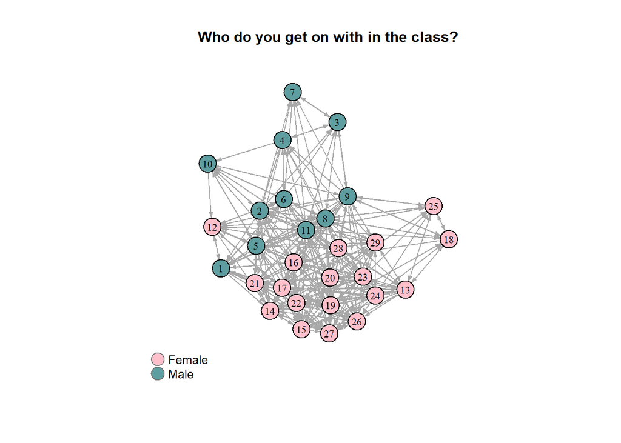

```r
#pdf(file="GetOnWith.pdf")
set.seed(77)
plot(g, layout=layout.fruchterman.reingold)
title("Who do you get on with in the class?", cex.main=1, col.main="black")
legend(x=-1.5, y=-1.1, c("Female","Male"), pch=21,col="#777777", pt.bg=c("pink", "cadetblue"), pt.cex=2, cex=.8, bty="n", ncol=1)
```

#### **1.3. Network Attributes**

##### **1.3.1. Centrality Measures: Degree Centrality**

```r
# Friends: Student #21 has the highest in-degree centrality in the Friends network.
  # Twelve students said she (#21) is one of their best friends.
degree(f, mode="in")
```

```
##  1  2  3  4  5  6  7  8  9 10 11 12 13 14 15 16 17 18 19 20 21 22 23 24 25 26
##  5  6  5  4  5  4  3  8  1  6  8  4  6 11  9  8  3  2  9 11 12 11 11  6  2  5
## 27 28 29
##  7  4  5
```

```r
which.max(degree(f, mode="in"))
```

```
## 21
## 21
```

```r
centr_degree(f, mode="in", normalized=T)
```

```
## $res
##  [1]  5  6  5  4  5  4  3  8  1  6  8  4  6 11  9  8  3  2  9 11 12 11 11  6  2
## [26]  5  7  4  5
##
## $centralization
## [1] 0.205665
##
## $theoretical_max
## [1] 812
```

```r
# Work with: Student #16 is probably a hard worker. Seventeen of her colleagues said they "would prefer to work" with her.
degree(w, mode="in")
```

```
##  1  2  3  4  5  6  7  8  9 10 11 12 13 14 15 16 17 18 19 20 21 22 23 24 25 26
##  4  7  7  4  7  6  3  6  0  3  8  3  2 12 13 17  5  2  9 11 13 11 12  9  2  7
## 27 28 29
##  9  2  4
```

```r
which.max(degree(w, mode="in"))
```

```
## 16
## 16
```

```r
centr_degree(w, mode="in", normalized=T)
```

```
## $res
##  [1]  4  7  7  4  7  6  3  6  0  3  8  3  2 12 13 17  5  2  9 11 13 11 12  9  2
## [26]  7  9  2  4
##
## $centralization
## [1] 0.3633005
##
## $theoretical_max
## [1] 812
```

```r
# Get on with: Students #14 & #16 have the highest in-degree centrality in the GetOn network.
  # Nineteen of their colleagues said they "get on with" them.
degree(g, mode="in")
```

```
##  1  2  3  4  5  6  7  8  9 10 11 12 13 14 15 16 17 18 19 20 21 22 23 24 25 26
## 10 14  7  8 14  7  7 12  6  7 15  9  9 19 15 19 13  7 18 17 17 17 17 13  8 18
## 27 28 29
## 16  9 13
```

```r
sort(degree(g, mode="in"))
```

```
##  9  3  6  7 10 18  4 25 12 13 28  1  8 17 24 29  2  5 11 15 27 20 21 22 23 19
##  6  7  7  7  7  7  8  8  9  9  9 10 12 13 13 13 14 14 15 15 16 17 17 17 17 18
## 26 14 16
## 18 19 19
```

```r
centr_degree(g, mode="in", normalized=T)
```

```
## $res
##  [1] 10 14  7  8 14  7  7 12  6  7 15  9  9 19 15 19 13  7 18 17 17 17 17 13  8
## [26] 18 16  9 13
##
## $centralization
## [1] 0.2339901
##
## $theoretical_max
## [1] 812
```

##### **1.3.2. Centrality Measures: Closeness Centrality**

```r
# Friends: Student 8 has the highest closeness centrality in this network.
  # It means that student #8 is who can reach all other individuals in the network "more quickly"
sort(closeness(f, mode="all", weights=NA))
```

```
##         18         25         26          7         12          3          4
## 0.01408451 0.01408451 0.01694915 0.01754386 0.01785714 0.01818182 0.01818182
##          1         10         17          9         23          6         27
## 0.01851852 0.01851852 0.01851852 0.01923077 0.01923077 0.01960784 0.02000000
##          2          5         19         29         16         24         28
## 0.02040816 0.02040816 0.02040816 0.02040816 0.02083333 0.02083333 0.02083333
##         15         13         20         21         22         14         11
## 0.02173913 0.02222222 0.02272727 0.02272727 0.02272727 0.02325581 0.02631579
##          8
## 0.03030303
```

```r
centr_clo(f, mode="all", normalized=T)
```

```
## $res
##  [1] 0.5185185 0.5714286 0.5090909 0.5090909 0.5714286 0.5490196 0.4912281
##  [8] 0.8484848 0.5384615 0.5185185 0.7368421 0.5000000 0.6222222 0.6511628
## [15] 0.6086957 0.5833333 0.5185185 0.3943662 0.5714286 0.6363636 0.6363636
## [22] 0.6363636 0.5384615 0.5833333 0.3943662 0.4745763 0.5600000 0.5833333
## [29] 0.5714286
##
## $centralization
## [1] 0.595079
##
## $theoretical_max
## [1] 13.74545
```

```r
# Work with: Student 6
sort(closeness(w, mode="all", weights=NA))
```

```
##         18         25          7         10          4          3         17
## 0.01351351 0.01351351 0.01587302 0.01639344 0.01724138 0.01818182 0.01886792
##         28          9         26          1         27         29          2
## 0.01886792 0.01923077 0.01923077 0.01960784 0.01960784 0.01960784 0.02083333
##         12         13          5         19         15         20         21
## 0.02083333 0.02083333 0.02127660 0.02272727 0.02325581 0.02325581 0.02325581
##         22         24         11         23         14          8         16
## 0.02325581 0.02325581 0.02439024 0.02439024 0.02564103 0.02631579 0.02631579
##          6
## 0.02702703
```

```r
centr_clo(w, mode="all", normalized=T)
```

```
## $res
##  [1] 0.5490196 0.5833333 0.5090909 0.4827586 0.5957447 0.7567568 0.4444444
##  [8] 0.7368421 0.5384615 0.4590164 0.6829268 0.5833333 0.5833333 0.7179487
## [15] 0.6511628 0.7368421 0.5283019 0.3783784 0.6363636 0.6511628 0.6511628
## [22] 0.6511628 0.6829268 0.6511628 0.3783784 0.5384615 0.5490196 0.5283019
## [29] 0.5490196
##
## $centralization
## [1] 0.3609286
##
## $theoretical_max
## [1] 13.74545
```

```r
# Get on with: Student 11
sort(closeness(g, mode="all", weights=NA))
```

```
##          3          7         18         25         10          4         12
## 0.02040816 0.02040816 0.02083333 0.02083333 0.02127660 0.02222222 0.02272727
##          1         17         29         21         28          6         13
## 0.02439024 0.02439024 0.02500000 0.02564103 0.02564103 0.02631579 0.02631579
##         15         20         26         27          2          5         14
## 0.02631579 0.02631579 0.02631579 0.02631579 0.02702703 0.02702703 0.02702703
##         19         22         23          9         16         24          8
## 0.02702703 0.02702703 0.02702703 0.02777778 0.02777778 0.02777778 0.03571429
##         11
## 0.03571429
```

```r
centr_clo(g, mode="all", normalized=T)
```

```
## $res
##  [1] 0.6829268 0.7567568 0.5714286 0.6222222 0.7567568 0.7368421 0.5714286
##  [8] 1.0000000 0.7777778 0.5957447 1.0000000 0.6363636 0.7368421 0.7567568
## [15] 0.7368421 0.7777778 0.6829268 0.5833333 0.7567568 0.7368421 0.7179487
## [22] 0.7567568 0.7567568 0.7777778 0.5833333 0.7368421 0.7368421 0.7179487
## [29] 0.7000000
##
## $centralization
## [1] 0.5848819
##
## $theoretical_max
## [1] 13.74545
```